# Practicum_2

### Part 1-1

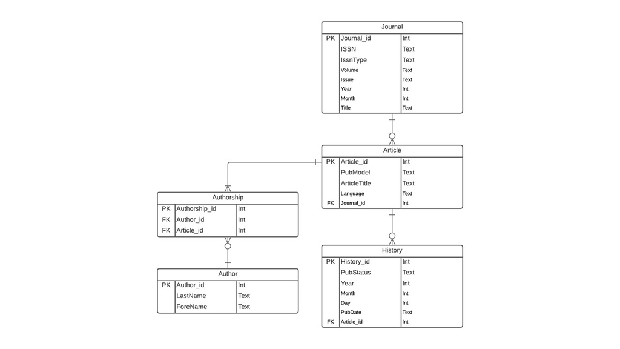

### Part 1-2

```r
library(RSQLite)

fpath = "c:/Users/tisda/Downloads/sqlite/"
dbfile = "pubmedDB.db"

dbcon <- dbConnect(RSQLite::SQLite(), paste0(fpath, dbfile))
```

Drop Journal Table if exists

```sql
DROP TABLE IF EXISTS Journal;
```

Create Journal Table

```sql
CREATE TABLE Journal(
  Journal_id INTEGER PRIMARY KEY AUTOINCREMENT,
  ISSN TEXT,
  IssnType TEXT,
  Volume TEXT,
  Issue TEXT,
  Year INT,
  Month INT,
  Title TEXT
);
```

Drop Article Table if exists

```sql
DROP TABLE IF EXISTS Article;
```

Create Article Table

```sql
CREATE TABLE Article(
  Article_id INTEGER PRIMARY KEY AUTOINCREMENT,
  PubModel TEXT,
  ArticleTitle TEXT,
  Language TEXT,
  Journal_id INT,
  FOREIGN KEY (Journal_id) REFERENCES Journal(Journal_id)
);
```

Drop History Table if exists

```sql
DROP TABLE IF EXISTS History;
```

Create History Table

```sql
CREATE TABLE History(
  History_id INTEGER PRIMARY KEY AUTOINCREMENT,
  PubStatus TEXT,
  Year INT,
  Month INT,
  Day INT,
  Pub_date TEXT,
  Article_id INT,
  FOREIGN KEY (Article_id) REFERENCES Article(Article_id)
);
```

Drop Author Table if exists

```sql
DROP TABLE IF EXISTS Author;
```

Create Author Table

```sql
CREATE TABLE Author(
  Author_id INTEGER PRIMARY KEY AUTOINCREMENT,
  LastName TEXT,
  ForeName TEXT
);
```

Drop Authorship Table if exists

```sql
DROP TABLE IF EXISTS Authorship;
```

Create Authorship Table

```sql
CREATE TABLE Authorship(
  Authorship_id INTEGER PRIMARY KEY AUTOINCREMENT,
  Author_id INT,
  Article_id INT,
  FOREIGN KEY (Author_id) REFERENCES Author(Author_id),
  FOREIGN KEY (Article_id) REFERENCES Article(Article_id)
);
```

### Problem 1-3

```r
library(XML)

my_xml <- "C:/Users/tisda/Downloads/pubmed_sample(1).xml"
xml_doc <- xmlParse(my_xml, validate = FALSE)

root_node <- xmlRoot(xml_doc)
num_articles <- xmlSize(root_node)

Article.df <- data.frame (Article_id = vector (mode = "integer", length = num_articles), PubModel = vector (mode = "character", length = num_articles), ArticleTitle = vector (mode = "character", length = num_articles), Language = vector (mode = "character", length = num_articles), Journal_id = vector (mode = "integer", length = num_articles), stringsAsFactors = F)

Journal.df <- data.frame (Journal_id = vector (mode = "integer", length = num_articles),
                          ISSN = vector (mode = "character", length = num_articles),
                          IssnType = vector (mode = "character", length = num_articles),
                          Volume = vector (mode = "character", length = num_articles),
                          Issue = vector (mode = "character", length = num_articles),
                          Year = vector (mode = "integer", length = num_articles),
                          Month = vector (mode = "integer", length = num_articles),
                          Title = vector (mode = "character", length = num_articles),
                          stringsAsFactors = F)
xpathEx = '//PubMedPubDate'
history_values <- xpathSApply(root_node, xpathEx)
num_histories <- length(history_values)
History.df <- data.frame (History_id = vector (mode = 'integer', length = num_histories),
                          PubStatus = vector (mode = 'character', length = num_histories),
                          Year = vector (mode = 'integer', length = num_histories),
                          Month = vector (mode = 'integer', length = num_histories),
                          Day = vector (mode = 'integer', length = num_histories),
                          Pub_date = vector (mode = 'character', length = num_histories),
                          Article_id = vector (mode = 'integer', length = num_histories),
                          stringsAsFactors = F)

xpathEx <- '//Author'
author_values <- xpathSApply(root_node, xpathEx)
num_authors <- length(author_values)

Author.df <- data.frame (Author_id = vector (mode = 'integer', length = num_authors),
                         LastName = vector (mode = 'character', length = num_authors),
                         ForeName = vector (mode = 'character', length = num_authors),
                         stringsAsFactors = F)

Authorship.df <- data.frame (Authorship_id = vector (mode = 'integer', length = num_authors),
                             Author_id = vector (mode = 'integer', length = num_authors),
                             Article_id = vector (mode = 'integer', length = num_authors),
                             stringsAsFactors = F)
```

Populate data frames

```r
xpathEx <- '//PubmedArticle/MedlineCitation/Article/@PubModel'
PubModel_values <- xpathSApply(root_node, xpathEx)

index <- 1
index2 <- 1

for (i in 1:num_articles){
  # populate Article data frame
  Article.df$Article_id[i] <- i
  Article.df$PubModel[i] <- PubModel_values[i]
  xpathEx1 = paste0('//PubmedArticle[',i, ']//ArticleTitle')
  Article.df$ArticleTitle[i] <- xpathSApply(root_node, xpathEx1, xmlValue)
  xpathEx2 = paste0('//PubmedArticle[',i,']//Language')
  Article.df$Language[i] <- xpathSApply(root_node, xpathEx2, xmlValue)
  Article.df$Journal_id[i] <- i

  # populate Journal data frame
  Journal.df$Journal_id[i] <- i
  xpathEx3 = paste0('//PubmedArticle[',i,']/MedlineCitation/Article/Journal/ISSN')
  Journal.df$ISSN[i] <- xpathSApply(root_node, xpathEx3, xmlValue)
  xpathEx4 = paste0('//PubmedArticle[',i,']/MedlineCitation/Article/Journal/ISSN/@IssnType')
  Journal.df$IssnType[i] <- xpathSApply(root_node, xpathEx4)
  xpathEx5 = paste0('//PubmedArticle[',i,']/MedlineCitation/Article/Journal/JournalIssue/Volume')
  Journal.df$Volume[i] <- xpathSApply(root_node, xpathEx5, xmlValue)
  xpathEx6 = paste0('//PubmedArticle[',i,']/MedlineCitation/Article/Journal/JournalIssue/Issue')
  Journal.df$Issue[i] <- xpathSApply(root_node, xpathEx6, xmlValue)
  xpathEx7 = paste0('//PubmedArticle[',i,']/MedlineCitation/Article/Journal/JournalIssue/PubDate')
  date_value <- xpathSApply(root_node, xpathEx7, xmlValue)
  cat_date_value <- gsub(" ", "", date_value)
  year <- substring(cat_date_value, 0, 4)
  month <- substring(cat_date_value, 5, 7)
  if (month == ''){
    month_num <- 1
  }
  else {
    month_num <- match(month, month.abb)
  }
  Journal.df$Year[i] <- as.numeric(year)
  Journal.df$Month[i] <- as.numeric(month_num)
  xpathEx8 = paste0('//PubmedArticle[',i,']/MedlineCitation/Article/Journal/Title')
  Journal.df$Title[i] <- xpathSApply(root_node, xpathEx8, xmlValue)

  # populate History data frame
  xpathEx9 = paste0('//PubmedArticle[',i,']//PubMedPubDate')
  histories_per_article <- xpathSApply(root_node, xpathEx9)
  num_hist_per_article <- length(histories_per_article)

  for (j in 1:num_hist_per_article){
    History.df$History_id[index] <- index
    xpathEx10 <- paste0('//PubmedArticle[',i,']/PubmedData/History/PubMedPubDate[',j,']/@PubStatus')
    History.df$PubStatus[index] <- xpathSApply(root_node, xpathEx10)
    xpathEx11 <- paste0('//PubmedArticle[',i,']/PubmedData/History/PubMedPubDate[',j,']/Year')
    History.df$Year[index] <- xpathSApply(root_node, xpathEx11, xmlValue)
    xpathEx12 <- paste0('//PubmedArticle[',i,']/PubmedData/History/PubMedPubDate[',j,']/Month')
    History.df$Month[index] <- xpathSApply(root_node, xpathEx12, xmlValue)
    xpathEx13 <- paste0('//PubmedArticle[',i,']/PubmedData/History/PubMedPubDate[',j,']/Day')
    History.df$Day[index] <- xpathSApply(root_node, xpathEx13, xmlValue)
    Pub_year <- xpathSApply(root_node, xpathEx11, xmlValue)
    Pub_month <- xpathSApply(root_node, xpathEx12, xmlValue)
    Pub_day <- xpathSApply(root_node, xpathEx13, xmlValue)
    if (nchar(Pub_month)==1){
      Pub_month <- paste0('0',Pub_month)
    }
    if (nchar(Pub_day)==1){
      Pub_day <- paste0('0',Pub_day)
    }
    history_date_char <- paste0(Pub_year,'-',Pub_month,'-',Pub_day)
    #history_date <- as.Date(history_date_char)
    History.df$Pub_date[index] <- history_date_char
    History.df$Article_id[index] <- i

    index <- index + 1
  }

  # populate Author and Authorship data frames
  xpathEx14 <- paste0('//PubmedArticle[',i,']//Author')
  authors_per_article <- xpathSApply(root_node, xpathEx14)
  num_authors_per_article <- length(authors_per_article)
  for (j in 1:num_authors_per_article){
    Author.df$Author_id[index2] <- index2
    xpathEx15 <- paste0('//PubmedArticle[',i,']/MedlineCitation/Article/AuthorList/Author[',j,']/LastName')
    Author.df$LastName[index2] <- xpathSApply(root_node, xpathEx15, xmlValue)
    xpathEx16 <- paste0('//PubmedArticle[',i,']/MedlineCitation/Article/AuthorList/Author[',j,']/ForeName')
    Author.df$ForeName[index2] <- xpathSApply(root_node, xpathEx16, xmlValue)

    Authorship.df$Authorship_id[index2] <- index2
    Authorship.df$Author_id[index2] <- index2
    Authorship.df$Article_id[index2] <- i

    index2 <- index2 + 1
  }


}
```

Change relevant columns to integers

```r
History.df$Year <- as.integer(as.character(History.df$Year))
History.df$Month <- as.integer(as.character(History.df$Month))
History.df$Day <- as.integer(as.character(History.df$Day))
#History.df$Pub_date <- as.Date(as.character(History.df$Pub_date))
```

Write all tables to SQLite database

```r
dbWriteTable(dbcon, "Journal", Journal.df, overwrite = TRUE)
dbWriteTable(dbcon, "Article", Article.df, overwrite = TRUE)
dbWriteTable(dbcon, "History", History.df, overwrite = TRUE)
dbWriteTable(dbcon, "Author", Author.df, overwrite = TRUE)
dbWriteTable(dbcon, "Authorship", Authorship.df, overwrite = TRUE)


#for (i in 1:length(History.df$History_id)){
#  sqlString1 <- paste0("INSERT INTO History VALUES #('",History.df$History_id[i],"','",History.df$PubSt#atus[i],"','",History.df$Year[i],"','",History.df$M#onth[i],"','",History.df$Day[i],"','",History.df$Pu#b_date[i],"','",History.df$Article_id[i],"');")

#  dbSendStatement(dbcon, sqlString1)

#}
```

Test Chunk: Show History Table

```sql
SELECT * FROM History
```

| History_id | PubStatus | Year | Month | Day | Pub_date | Article_id |
| --- | --- | --- | --- | --- | --- | --- |
| 1 | received | 2012 | 1 | 15 | 2012-01-15 | 1 |
| 2 | accepted | 2012 | 4 | 16 | 2012-04-16 | 1 |
| 3 | epublish | 2012 | 6 | 20 | 2012-06-20 | 1 |
| 4 | entrez | 2013 | 7 | 23 | 2013-07-23 | 1 |
| 5 | pubmed | 2013 | 7 | 23 | 2013-07-23 | 1 |
| 6 | medline | 2013 | 7 | 23 | 2013-07-23 | 1 |
| 7 | received | 2012 | 7 | 16 | 2012-07-16 | 2 |
| 8 | revised | 2012 | 8 | 17 | 2012-08-17 | 2 |
| 9 | accepted | 2012 | 8 | 20 | 2012-08-20 | 2 |
| 10 | aheadofprint | 2012 | 11 | 27 | 2012-11-27 | 2 |

[output cut: 84 more lines]

### Part 2-1

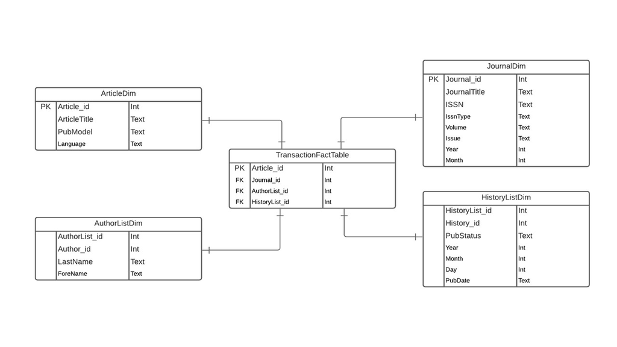

Create Star Schema: Part 2-1

```sql
DROP TABLE IF EXISTS AuthorListDim
```

Create AuthorListDim Dimension Table

```sql
CREATE TABLE AuthorListDim(
  AuthorList_id INT,
  Author_id INT,
  LastName TEXT,
  ForeName TEXT
)
```

```sql
DROP TABLE IF EXISTS HistoryListDim
```

Create HistoryListDim Dimension Table

```sql
CREATE TABLE HistoryListDim(
  HistoryList_id INT,
  History_id INT,
  PubStatus TEXT,
  Year INT,
  Month INT,
  Day INT,
  Pub_date TEXT
)
```

```sql
DROP TABLE IF EXISTS JournalDim;
```

Create JournalDim Dimension Table

```sql
CREATE TABLE JournalDim(
  Journal_id INT PRIMARY KEY,
  JournalTitle TEXT,
  ISSN TEXT,
  IssnType TEXT,
  Volume TEXT,
  Issue TEXT,
  Year INT,
  Month INT
)
```

```sql
DROP TABLE IF EXISTS ArticleDim;
```

Create ArticleDim Dimension Table

```sql
CREATE TABLE ArticleDim(
  Article_id INT PRIMARY KEY,
  ArticleTitle TEXT,
  PubModel TEXT,
  Language TEXT
)
```

```sql
DROP TABLE IF EXISTS TransactionFactTable
```

Create TransactionFactTable

```sql
CREATE TABLE TransactionFactTable(
  Article_id INT PRIMARY KEY,
  Journal_id INT,
  AuthorList_id INT,
  HistoryList_id INT,
  FOREIGN KEY (Article_id) REFERENCES ArticleDim(Article_id),
  FOREIGN KEY (Journal_id) REFERENCES JournalDim(Journal_id),
  FOREIGN KEY (AuthorList_id) REFERENCES AuthorListDim(AuthorList_id),
  FOREIGN KEY (HistoryList_id) REFERENCES HistoryListDim(HistoryList_id)
)
```

Populate Star Schema: Part 2-1 Populate AuthorListDim table

```r
sql_statement <- 'INSERT INTO AuthorListDim(AuthorList_id, Author_id, LastName, ForeName)
SELECT Article_id AS AuthorList_id, Author_id, LastName, ForeName FROM Author
JOIN Authorship USING (Author_id);'
dbSendStatement(dbcon, sql_statement)
```

```
<SQLiteResult>
  SQL  INSERT INTO AuthorListDim(AuthorList_id, Author_id, LastName, ForeName)
SELECT Article_id AS AuthorList_id, Author_id, LastName, ForeName FROM Author
JOIN Authorship USING (Author_id);
  ROWS Fetched: 0 [complete]
       Changed: 136
```

Populate HistoryListDim table

```r
sql_statement <- 'INSERT INTO HistoryListDim(HistoryList_id, History_id, PubStatus, Year, Month, Day, Pub_date)
SELECT Article_id AS HistoryList_id, History_id, PubStatus, Year, Month, Day, Pub_date FROM History;'

dbSendStatement(dbcon, sql_statement)
```

```
Closing open result set, pending rows
```

```
<SQLiteResult>
  SQL  INSERT INTO HistoryListDim(HistoryList_id, History_id, PubStatus, Year, Month, Day, Pub_date)
SELECT Article_id AS HistoryList_id, History_id, PubStatus, Year, Month, Day, Pub_date FROM History;
  ROWS Fetched: 0 [complete]
       Changed: 94
```

Populate ArticleDim table

```r
sql_statement <- 'INSERT INTO ArticleDim(Article_id, ArticleTitle, PubModel, Language)
SELECT Article_id, ArticleTitle, PubModel, Language
FROM Article'
dbSendStatement(dbcon, sql_statement)
```

```
Closing open result set, pending rows
```

```
<SQLiteResult>
  SQL  INSERT INTO ArticleDim(Article_id, ArticleTitle, PubModel, Language)
SELECT Article_id, ArticleTitle, PubModel, Language
FROM Article
  ROWS Fetched: 0 [complete]
       Changed: 19
```

Populate JournalDim Table

```r
sql_statement <- 'INSERT INTO JournalDim(Journal_id, JournalTitle, ISSN, IssnType, Volume, Issue, Year, Month)
SELECT Journal_id, Title AS JournalTitle, ISSN, IssnType, Volume, Issue, Year, Month
FROM Journal;'
dbSendStatement(dbcon, sql_statement)
```

```
Closing open result set, pending rows
```

```
<SQLiteResult>
  SQL  INSERT INTO JournalDim(Journal_id, JournalTitle, ISSN, IssnType, Volume, Issue, Year, Month)
SELECT Journal_id, Title AS JournalTitle, ISSN, IssnType, Volume, Issue, Year, Month
FROM Journal;
  ROWS Fetched: 0 [complete]
       Changed: 19
```

Populate TransactionFactTable

```r
sql_statement <- 'INSERT INTO TransactionFactTable(Article_id, Journal_id, AuthorList_id, HistoryList_id)
SELECT Article_id, Article_id AS Journal_id, Article_id AS AuthorList_id, Article_id AS HistoryList_id FROM Article;'
dbSendStatement(dbcon, sql_statement)
```

```
Closing open result set, pending rows
```

```
<SQLiteResult>
  SQL  INSERT INTO TransactionFactTable(Article_id, Journal_id, AuthorList_id, HistoryList_id)
SELECT Article_id, Article_id AS Journal_id, Article_id AS AuthorList_id, Article_id AS HistoryList_id FROM Article;
  ROWS Fetched: 0 [complete]
       Changed: 19
```

### Part 2-2

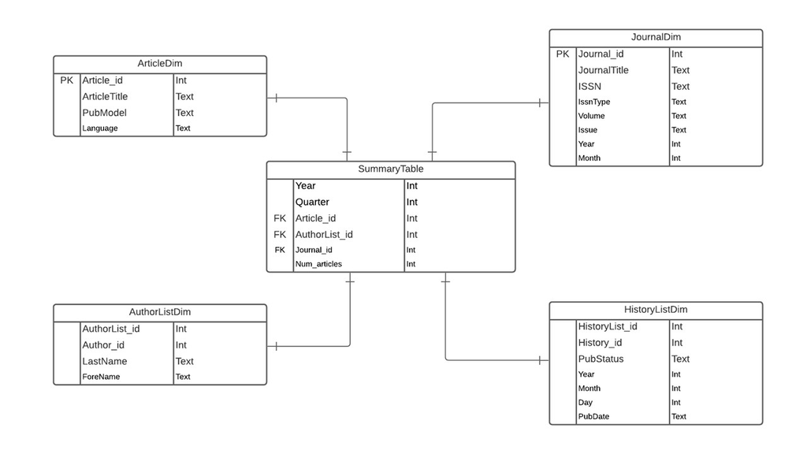

```sql
DROP TABLE IF EXISTS SummaryTable
```

Create SummaryTable

```sql
CREATE TABLE SummaryTable(
  Year INT,
  Quarter INT,
  Article_id INT,
  AuthorList_id INT,
  Journal_id INT,
  HistoryList_id INT,
  Num_articles INT,
  FOREIGN KEY (Article_id) REFERENCES ArticleDim(Article_id),
  FOREIGN KEY (AuthorList_id) REFERENCES AuthorListDim(AuthorList_id),
  FOREIGN KEY (Journal_id) REFERENCES JournalDim(Journal_id),
  FOREIGN KEY (HistoryList_id) REFERENCES HistoryListDim(HistoryList_id)
);
```

```sql
DROP TABLE IF EXISTS SummaryTest;
```

Create SummaryTest Table This is a preliminary table that is necessary to build the SummaryTable

```sql
CREATE TABLE SummaryTest(
  Year INT,
  Quarter INT,
  Article_id INT,
  AuthorList_id INT,
  Journal_id INT,
  HistoryList_id INT
)
```

Create SummaryTest.df and populate SummaryTest Table

```r
num_articles <- nrow(Article.df)
SummaryTest.df <- data.frame (Year = vector (mode = "integer", length = num_articles),
                              Quarter = vector (mode = "integer", length = num_articles),
                              Article_id = vector (mode = "integer", length = num_articles),
                              AuthorList_id = vector (mode = "integer", length = num_articles),
                              Journal_id = vector (mode = "integer", length = num_articles),
                              HistoryList_id = vector (mode = "integer", length = num_articles),
                              stringsAsFactors = F)

sql_statement <- 'INSERT INTO SummaryTest(Year, Quarter, Article_id, AuthorList_id, Journal_id, HistoryList_id) SELECT Year,
CASE
  WHEN JournalDim.Month < 4 THEN 1
  WHEN JournalDim.Month < 7 THEN 2
  WHEN JournalDim.Month < 10 THEN 3
  WHEN JournalDim.Month < 13 THEN 4
END AS Quarter,
Article_id, AuthorList_id, Journal_id, HistoryList_id
FROM TransactionFactTable
JOIN JournalDim USING (Journal_id)
ORDER BY Article_id;'

dbSendStatement(dbcon, sql_statement)
```

```
<SQLiteResult>
  SQL  INSERT INTO SummaryTest(Year, Quarter, Article_id, AuthorList_id, Journal_id, HistoryList_id) SELECT Year,
CASE
  WHEN JournalDim.Month < 4 THEN 1
  WHEN JournalDim.Month < 7 THEN 2
  WHEN JournalDim.Month < 10 THEN 3
  WHEN JournalDim.Month < 13 THEN 4
END AS Quarter,
Article_id, AuthorList_id, Journal_id, HistoryList_id
FROM TransactionFactTable
JOIN JournalDim USING (Journal_id)
ORDER BY Article_id;
  ROWS Fetched: 0 [complete]
       Changed: 19
```

```r
SummaryTest.df <- dbReadTable(dbcon, 'SummaryTest')
```

```
Closing open result set, pending rows
```

```r
SummaryTest.df
```

| Year | Quarter | Article_id | AuthorList_id | Journal_id | HistoryList_id |
| --- | --- | --- | --- | --- | --- |
| 2012 | 3 | 1 | 1 | 1 | 1 |
| 2013 | 1 | 2 | 2 | 2 | 2 |
| 2012 | 4 | 3 | 3 | 3 | 3 |
| 2012 | 4 | 4 | 4 | 4 | 4 |
| 2013 | 1 | 5 | 5 | 5 | 5 |
| 2013 | 1 | 6 | 6 | 6 | 6 |
| 2012 | 4 | 7 | 7 | 7 | 7 |
| 2012 | 3 | 8 | 8 | 8 | 8 |
| 2012 | 3 | 9 | 9 | 9 | 9 |
| 2012 | 2 | 10 | 10 | 10 | 10 |

[output cut: 9 more lines]

```sql
DROP TABLE IF EXISTS GetNumArticles;
```

Create GetNumArticles Table This is another temporary table to help create SummaryTable later on.

```sql
CREATE TABLE GetNumArticles(
  Year INT,
  Quarter INT,
  Num_articles INT
)
```

Create GetNumArticles.df

```r
num_rows <- 5
GetNumArticles.df <- data.frame (Year = vector (mode = "integer", length = num_rows),
                                 Quarter = vector (mode = "integer", length = num_rows),
                                 Num_articles = vector (mode = "integer", length = num_rows),
                                 stringsAsFactors = F)

sql_statement <- 'INSERT INTO GetNumArticles(Year, Quarter, Num_articles) SELECT Year,
CASE
  WHEN JournalDim.Month < 4 THEN 1
  WHEN JournalDim.Month < 7 THEN 2
  WHEN JournalDim.Month < 10 THEN 3
  WHEN JournalDim.Month < 13 THEN 4
END AS Quarter,
COUNT(Article_id) AS Num_articles
FROM TransactionFactTable
JOIN JournalDim USING (Journal_id)
GROUP BY Year, Quarter;'

dbSendStatement(dbcon, sql_statement)
```

```
<SQLiteResult>
  SQL  INSERT INTO GetNumArticles(Year, Quarter, Num_articles) SELECT Year,
CASE
  WHEN JournalDim.Month < 4 THEN 1
  WHEN JournalDim.Month < 7 THEN 2
  WHEN JournalDim.Month < 10 THEN 3
  WHEN JournalDim.Month < 13 THEN 4
END AS Quarter,
COUNT(Article_id) AS Num_articles
FROM TransactionFactTable
JOIN JournalDim USING (Journal_id)
GROUP BY Year, Quarter;
  ROWS Fetched: 0 [complete]
       Changed: 5
```

```r
GetNumArticles.df <- dbReadTable(dbcon, 'GetNumArticles')
```

```
Closing open result set, pending rows
```

```r
GetNumArticles.df
```

| Year | Quarter | Num_articles |
| --- | --- | --- |
| 2012 | 1 | 5 |
| 2012 | 2 | 4 |
| 2012 | 3 | 4 |
| 2012 | 4 | 3 |
| 2013 | 1 | 3 |

Populate SummaryTable

```r
num_rows <- 22
SummaryTable.df <- data.frame (Year = vector (mode = "integer", length = num_rows),
                                Quarter = vector (mode = "integer", length = num_rows),
                                 Article_id = vector (mode = "integer", length = num_rows),
                                  AuthorList_id = vector (mode = "integer", length = num_rows),
                                   Journal_id = vector (mode = "integer", length = num_rows),
                               HistoryList_id = vector (mode = "integer", length = num_rows),
                                    Num_articles = vector (mode = "integer", length = num_rows),
                                    stringsAsFactors = F)

index <- 1
for (i in 2012:2013){
  for (j in 1:4){
    alpha <- 0
    for (k in 1:nrow(Article.df)){
      if (SummaryTest.df$Year[k] == i &
          SummaryTest.df$Quarter[k] == j){
        SummaryTable.df$Year[index] <- i
        SummaryTable.df$Quarter[index] <- j
        SummaryTable.df$Article_id[index] <- k
        SummaryTable.df$AuthorList_id[index] <- k
        SummaryTable.df$Journal_id[index] <- k
        SummaryTable.df$HistoryList_id[index] <- k
        alpha <- 1
        num_articles <- 0
        for (l in 1:5){
          if (GetNumArticles.df$Year[l] == i &
              GetNumArticles.df$Quarter[l] == j){
            num_articles <- GetNumArticles.df$Num_articles[l]
            }
      }
        SummaryTable.df$Num_articles[index] <- num_articles
        index <- index + 1
      }

    }
    if (alpha == 0){
        SummaryTable.df$Year[index] <- i
        SummaryTable.df$Quarter[index] <- j
        SummaryTable.df$Article_id[index] <- 0
        SummaryTable.df$AuthorList_id[index] <- 0
        SummaryTable.df$Journal_id[index] <- 0
        SummaryTable.df$HistoryList_id[index] <- 0
        SummaryTable.df$Num_articles[index] <- 0
        index <- index + 1
    }
  }
}
dbWriteTable(dbcon, 'SummaryTable', SummaryTable.df, overwrite = TRUE)
```

Show SummaryTable

```sql
SELECT * FROM SummaryTable;
```

| Year | Quarter | Article_id | AuthorList_id | Journal_id | HistoryList_id | Num_articles |
| --- | --- | --- | --- | --- | --- | --- |
| 2012 | 1 | 11 | 11 | 11 | 11 | 5 |
| 2012 | 1 | 12 | 12 | 12 | 12 | 5 |
| 2012 | 1 | 13 | 13 | 13 | 13 | 5 |
| 2012 | 1 | 17 | 17 | 17 | 17 | 5 |
| 2012 | 1 | 19 | 19 | 19 | 19 | 5 |
| 2012 | 2 | 10 | 10 | 10 | 10 | 4 |
| 2012 | 2 | 14 | 14 | 14 | 14 | 4 |
| 2012 | 2 | 15 | 15 | 15 | 15 | 4 |
| 2012 | 2 | 16 | 16 | 16 | 16 | 4 |
| 2012 | 3 | 1 | 1 | 1 | 1 | 4 |

[output cut: 12 more lines]

### Problem 3-1

[figure not shown]

```r
rs <- dbGetQuery(dbcon, "SELECT Year, Quarter, Num_articles
FROM SummaryTable
GROUP BY Year, Quarter;")

barplot(rs$Quarter, rs$Num_articles,
        main = "Articles per Quarter",
        xlab = "2012 - 2013",
        ylab = "Number Articles",
        names.arg = c("Q1","Q2","Q3","Q4", "Q1", "Q2", "Q3", "Q4"),
        col = "darkred")
```

The below bar graph shows number of days till publication for each article.

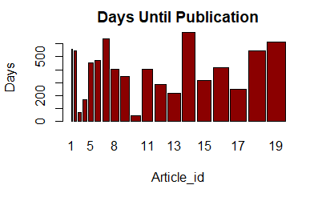

```r
rs <- dbGetQuery(dbcon, "SELECT Article_id, min_date, max_date, JULIANDAY(Date(max_date)) - JULIANDAY(Date(min_date)) AS date_difference FROM
(SELECT HistoryList_id, Article_id, History_id, MIN(Date(Pub_date)) AS min_date, MAX(Date(Pub_date)) AS max_date FROM HistoryListDim
JOIN TransactionFactTable USING (HistoryList_id)
GROUP BY HistoryList_id)
GROUP BY Article_id;")

barplot(rs$date_difference, rs$Article_id,
        main = "Days Until Publication",
        xlab = "Article_id",
        ylab = "Days",
        names.arg = c("1","2","3","4","5","6","7","8","9","10","11","12","13","14","15","16","17","18","19"),
        col = "darkred")
```

Below is a line graph which shows the ammount of days it took to publish an article per quarter.

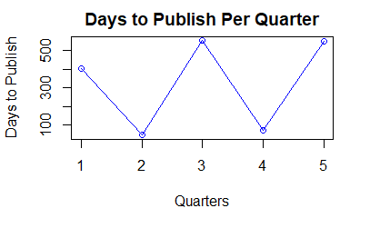

```r
rs <- dbGetQuery(dbcon, "SELECT Year, Quarter, JULIANDAY(Date(max_date)) - JULIANDAY(Date(min_date)) AS date_difference FROM
(SELECT HistoryList_id, SummaryTable.Year AS Year, Quarter, MIN(Date(Pub_date)) AS min_date, MAX(Date(Pub_date)) AS max_date FROM SummaryTable
JOIN HistoryListDim USING (HistoryList_id)
GROUP BY HistoryList_id)
GROUP BY Year,Quarter;")

plot(rs$date_difference, type = "o", xlab = "Quarters", ylab = "Days to Publish", main = "Days to Publish Per Quarter", col = "blue")
```

```r
dbDisconnect(dbcon)
```